# Relationship between antidepressant prescriptions and education across Scotland

2025-11-04

## Background

The relationship between mental health and education level has been studied extensively, with a number of theories emerging on how the two interact. Correlative trends have been observed in PhD students, possibly owing to increased stress (1.). While other studies have shown a significantly reduced incidence of mental illness in educated individuals, hypothesising a protective effect (2.).

This report aims to explore the relationship between antidepressant prescriptions and education level across Scotland, using Public Health Scotland prescribing data, and data from Scotland’s most recent census in 2022. The prescribing data will be taken from January to August 2025 and a monthly average calculated, minimising any recording of repeat prescriptions following the NHS’ prescribing recommendations indicating an optimal 28-day repeat prescription duration (3, 4.).

## Part 1: Exploring the relationship

Prescribing data can be found here: https://www.opendata.nhs.scot/dataset/prescriptions-in-the-community

```r
library(tidyverse)
library(stringr)
library(janitor)
library(here)
library(ggrepel)
library(readr)
library(dplyr)
library(gt)

urls <- c(
  "https://www.opendata.nhs.scot/dataset/84393984-14e9-4b0d-a797-b288db64d088/resource/cdd756fa-566e-4c91-b489-bcb0721e7c21/download/pitc202501.csv",
  "https://www.opendata.nhs.scot/dataset/84393984-14e9-4b0d-a797-b288db64d088/resource/54ec3c6d-f4c5-4653-be4f-741b634c18cf/download/pitc202502.csv",
  "https://www.opendata.nhs.scot/dataset/84393984-14e9-4b0d-a797-b288db64d088/resource/9849b4dd-b130-4a81-96a7-5bd00db5e2a9/download/pitc202503.csv",
  "https://www.opendata.nhs.scot/dataset/84393984-14e9-4b0d-a797-b288db64d088/resource/a36a1902-da40-4063-a103-ee3934b7623e/download/pitc202504.csv",
  "https://www.opendata.nhs.scot/dataset/84393984-14e9-4b0d-a797-b288db64d088/resource/a4410a3c-0e75-4b7f-927a-4d7af6436934/download/pitc202505.csv",
  "https://www.opendata.nhs.scot/dataset/84393984-14e9-4b0d-a797-b288db64d088/resource/0f2931af-3d08-4a6b-92cf-b61be4ce8d97/download/pitc202506.csv",
  "https://www.opendata.nhs.scot/dataset/84393984-14e9-4b0d-a797-b288db64d088/resource/12448904-f11c-4a0f-8dab-8b47c5abebf8/download/pitc202507.csv",
  "https://www.opendata.nhs.scot/dataset/84393984-14e9-4b0d-a797-b288db64d088/resource/381166dd-3a07-4c12-93c3-6db7b12c042a/download/pitc202508.csv") # 8 months of prescribing data through 2025

months <- seq(as.Date("2025-01-01"), as.Date("2025-08-01"), by = "month")

all_prescribing <- map2_df(urls, months, ~ read_csv(.x, col_types = cols(DMDCode = col_character(), .default = col_guess()), show_col_types = FALSE) %>%
    mutate(month = .y))
```

First, we need to find all the antidepressants being prescribed in Scotland. This is made possible by the inclusion of BNF item codes in the Public Health Scotland prescribing data set. By identifying the relevant codes for antidepressants we can filter the data set down to just the drugs we want to look at.

In order to identify the code for antidepressants, we can look at the BNF code information provided by the NHS Business Services Authority.

BNF information is available at: https://opendata.nhsbsa.net/dataset/bnf-code-information-current-year

```r
BNF_info <- read_csv(here("data/bnf_code_current_202506_version_88.csv"))

# We filter the data to show just the antidepressants
BNF_info_antidepressants <- BNF_info %>%
  filter(BNF_SECTION == "Antidepressant drugs")

unique(BNF_info_antidepressants$BNF_SECTION_CODE)
```

```
## [1] "0403"
```

Now we can see the section code, 0403, and we could also get the codes for specific antidepressant drugs and even formulations or dosages if needed.

Let’s use this information to filter the original data set, and we’ll calculate the average monthly prescribing numbers to set us up for exploring the research question.

```r
antidepressants <- all_prescribing %>%
  filter(str_starts(BNFItemCode, "0403"), HBT != "SB0806") # remove special health board as we filter for antidepressants

hb_month <- antidepressants %>%
  group_by(HBT, month) %>%
  summarise(total_items = sum(NumberOfPaidItems, na.rm = TRUE), .groups = "drop") # summing the number of monthly antidepressant prescriptions for each health board

hb_avg <- hb_month %>%
  group_by(HBT) %>%
  summarise(mean_items = mean(total_items, na.rm = TRUE), .groups = "drop") # prescription averages for each health board across the 8 months
```

Next, let’s add some names for the healthboard to our table, to allow for clearer visualisation down the line, and we can get an idea of the range of total prescriptions across Scotland.

Health board names available at: https://www.opendata.nhs.scot/dataset/geography-codes-and-labels/resource/652ff726-e676-4a20-abda-435b98dd7bdc

```r
hb_names <- read_csv("https://www.opendata.nhs.scot/dataset/9f942fdb-e59e-44f5-b534-d6e17229cc7b/resource/652ff726-e676-4a20-abda-435b98dd7bdc/download/hb14_hb19.csv")

data_antidepressants <- hb_names %>%
  inner_join(hb_avg, by = c("HB" = "HBT")) %>%
  clean_names() %>%
  select(!c(hb_date_enacted, hb_date_archived, country)) %>%
  mutate(hb_name = gsub("^NHS ", "", hb_name)) # removes NHS prefix for each health board to match the naming conventions in the census data
```

Using the flexible table builder on the Scottish census website, I have created a table with the numbers for the highest level of education (columns) achieved by healthboard (rows). We can join this with the data for antidepressants, using the healthboard names we just added.

Resource is available at: https://www.scotlandscensus.gov.uk/search-the-census#/

```r
# we have to load the census data as raw text to extract just the information we need
raw_lines <- read_lines(here("data/education_level_healthboard.csv"))
info <- raw_lines[10:25] # keep only the headers and the data (lines 10–25), also excluding the extra total row we don't need
info <- info[-2] # remove the extra header line

census_data22 <- read_csv(
  I(info), # feed character vector as a connection
  col_names = TRUE, show_col_types = FALSE) %>%
  clean_names() %>%
  rename(hb = highest_level_of_qualification) %>%
  select(hb, degree_level_qualifications_or_above_education_qualifications_not_already_mentioned_including_foreign_qualifications,total) # select only the columns we need to answer the question; we only need the last columns for education level since we're looking at the percentage of degree holders in each health board

education_antidepressants <- data_antidepressants %>%
  full_join(census_data22, by = c("hb_name" = "hb"))
```

Because all we have right now are flat numbers, we need to show these as proportions to properly gauge the relative prescribing rate of antidepressants. Luckily, we have a “total” column from the census data that shows us the population of each healthboard, so we can create a new column with the antidepressant prescriptions per capita from it.

Once we’ve done that, we can investigate the prescribing rates of the health boards.

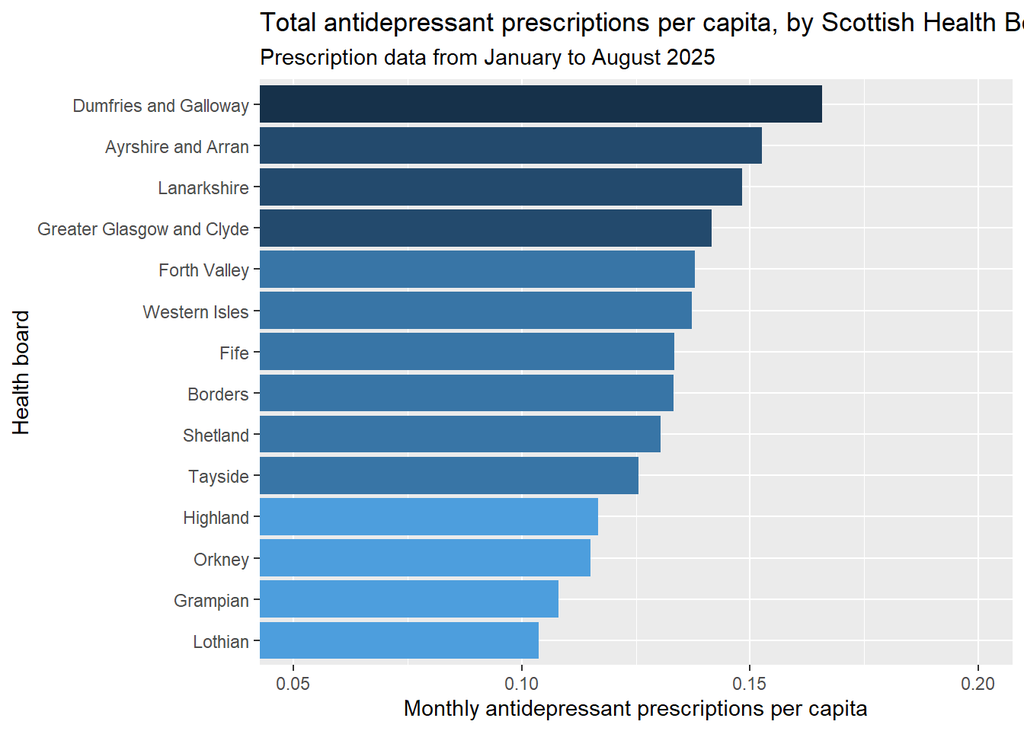

```r
education_antidepressants <- education_antidepressants %>%
  mutate(ratio = mean_items / total, degree_pct = degree_level_qualifications_or_above_education_qualifications_not_already_mentioned_including_foreign_qualifications/total*100) # total prescriptions per capita and percentage of degree holders in each healthboard

education_antidepressants %>%
  ggplot(aes(ratio, reorder(hb_name, ratio), fill = ratio)) +
  geom_col(stat="identity") +
  coord_cartesian(xlim=c(0.05, 0.2)) + # zoom in on the disparities between boards
  labs(x = "Monthly antidepressant prescriptions per capita", y = "Health board", title = "Total antidepressant prescriptions per capita, by Scottish Health Board", subtitle = "Prescription data from January to August 2025") +
  scale_fill_steps(low = "#56B1F7", high = "#132B43") +
  guides(fill = "none")
```

Now, we can explore the relationship between these antidepressant prescription rates and the education data. We’ll do this by using the percentage of each health board’s population that are degree holders as calculated earlier, and running a linear regression to determine the correlation between the two variables.

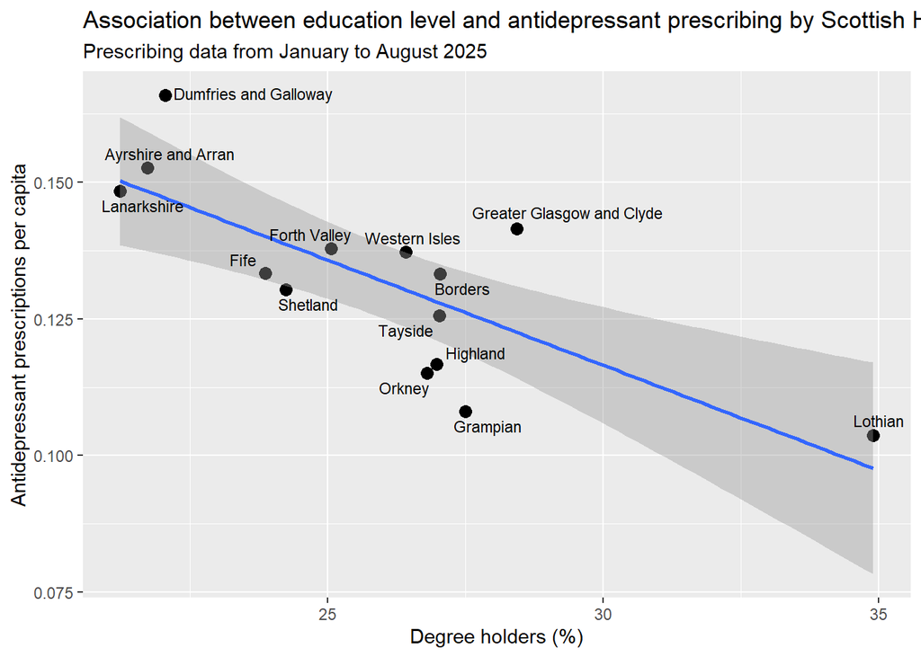

```r
ggplot(education_antidepressants, aes(x = degree_pct, y = ratio)) +
  geom_point(size = 3) +
  geom_smooth(method = "lm", se = TRUE) +
  geom_text_repel(aes(label = hb_name), size = 3) +
  labs(
    x = "Degree holders (%)",
    y = "Antidepressant prescriptions per capita",
    title = "Association between education level and antidepressant prescribing by Scottish Health board",
    subtitle = "Prescribing data from January to August 2025"
  )
```

A surface level interpretation of this graph says that there is a strong negative correlation between the variables: health boards with a higher percentage of degree holders have a lower antidepressant prescribing rate. To take just the extremes, Dumfries and Galloway with the highest prescribing rate sits at the far left of the graph, among the bottom health boards in degree attainment, while Lothian has the lowest prescribing rate and is directly juxtaposed, with the highest degree attainment by a large margin. In isolation, this is a strong point backing the negative correlation.

However, the standard error is of moderate size, and the majority of the health boards are distributed quite close to each other in education level, while still displaying a range of prescription rates, detracting from the credibility of the suggested relationship.

It is clear there is variation in the variables, and possibly a relationship between them, but the geographical stratification is too large at the level of health boards. To try and get a clearer image of the relationship, let’s do the same analysis, but with Scottish data zones, focusing in on much smaller localities.

## Part 2: Focusing in

The original prescribing data already had GP practice codes, so we can map the prescriptions to data zones using a practice lookup data set from Public Health Scotland. After that we’ll do the same as we did to the prescribing data before, finding the total prescriptions per month and then averaging, just this time by data zone instead of health board.

GP practices and list sizes October 2025 available from: https://www.opendata.nhs.scot/dataset/gp-practice-contact-details-and-list-sizes/resource/47557411-7eda-4278-9d6d-d26ed2ceab5a?inner_span=True

```r
## load in practice details
practice_info <- read_csv("https://www.opendata.nhs.scot/dataset/f23655c3-6e23-4103-a511-a80d998adb90/resource/47557411-7eda-4278-9d6d-d26ed2ceab5a/download/practice_contact_details_20251001_opendata.csv") %>% clean_names()

antidepressants_practice <- antidepressants %>%
  inner_join(practice_info, by = c("GPPractice" = "practice_code")) %>%
  select(c(GPPractice, NumberOfPaidItems, month, data_zone))

dz_month <- antidepressants_practice %>%
  group_by(data_zone, month) %>%
  summarise(total_items = sum(NumberOfPaidItems, na.rm = TRUE), .groups = "drop") # total prescriptions per month for each data zone

dz_avg <- dz_month %>%
  group_by(data_zone) %>%
  summarise(mean_items = mean(total_items, na.rm = TRUE), .groups = "drop") # average monthly prescriptions from Jan-Aug 2025 for each data zone
```

Next, we’ll load in the census data set with the education levels as columns and data zones as rows. Again, we’re using the flexible table builder so we’ll do some pre-processing to get the data ready.

```r
## load in census data by data zone instead of health board
read_lines(here("data/census_education_dz.csv"), n_max = 20)
```

```
##  [1] "SuperWEB2(tm)"
##  [2] ""
##  [3] "\"Person\""
##  [4] "\"Data Zone (2011) by Highest level of qualification\""
##  [5] "\"Counting: Individuals\""
##  [6] ""
##  [7] "Filters:"
##  [8] "\"Default Summation\",\"Individuals\""
##  [9] ""
## [10] "\"Highest level of qualification\",\"Not applicable (aged less than 16) \",\"No qualifications\",\"Lower school qualifications\",\"Upper school qualifications\",\"Apprenticeship qualifications\",\"Further Education and sub-degree Higher Education qualifications incl. HNC/HNDs\",\"Degree lev…
## [11] "\"Data Zone (2011)\","
## [12] "\"S01006506\",147,84,136,80,65,102,355,969,"
## [13] "\"S01006507\",125,118,124,54,45,77,215,758,"
## [14] "\"S01006508\",92,37,88,42,28,62,192,542,"
## [15] "\"S01006509\",108,67,80,40,55,56,154,560,"
## [16] "\"S01006510\",95,74,110,55,56,54,170,621,"
## [17] "\"S01006511\",111,65,87,59,44,77,265,703,"
## [18] "\"S01006512\",91,54,72,56,37,55,232,598,"
## [19] "\"S01006513\",266,126,78,47,37,83,492,1129,"
## [20] "\"S01006514\",226,49,90,82,34,80,479,1040,"
```

```r
census_dz <- read_csv(here("data/census_education_dz.csv"), skip = 9, col_names = TRUE) %>%
  slice(-1) %>% # removing misformatted row
  remove_empty("cols") %>%
  rename(data_zone = "Highest level of qualification") %>%
  filter(str_detect(data_zone, "^S\\d{8}$")) %>% # remove irrelevant rows/data zones not complicit with desired pattern
  clean_names()

antidepressants_education_dz <- inner_join(dz_avg, census_dz, by = c("data_zone" = "data_zone"))


raw_lines_dz <- read_lines(here("data/census_education_dz.csv"))
dz_rows <- grep('^"S\\d{8}"', raw_lines_dz) # use regex to find just the rows with the data we need
core_text_dz <- c(raw_lines_dz[10], raw_lines_dz[dz_rows]) # combine header row with the data

census_dz <- read_csv(
  I(core_text_dz), # character vector fed in
  show_col_types = FALSE) %>%
  clean_names() %>%
  rename(data_zone = highest_level_of_qualification) %>%
  select(data_zone, degree_level_qualifications_or_above_education_qualifications_not_already_mentioned_including_foreign_qualifications, total) # only need these columns for investigation

antidepressants_education_dz <- inner_join(dz_avg, census_dz)
```

Now, we can just add the antidepressants per capita and degree holder % to the data set and we can get a similar linear regression to what we had above, with data zones this time.

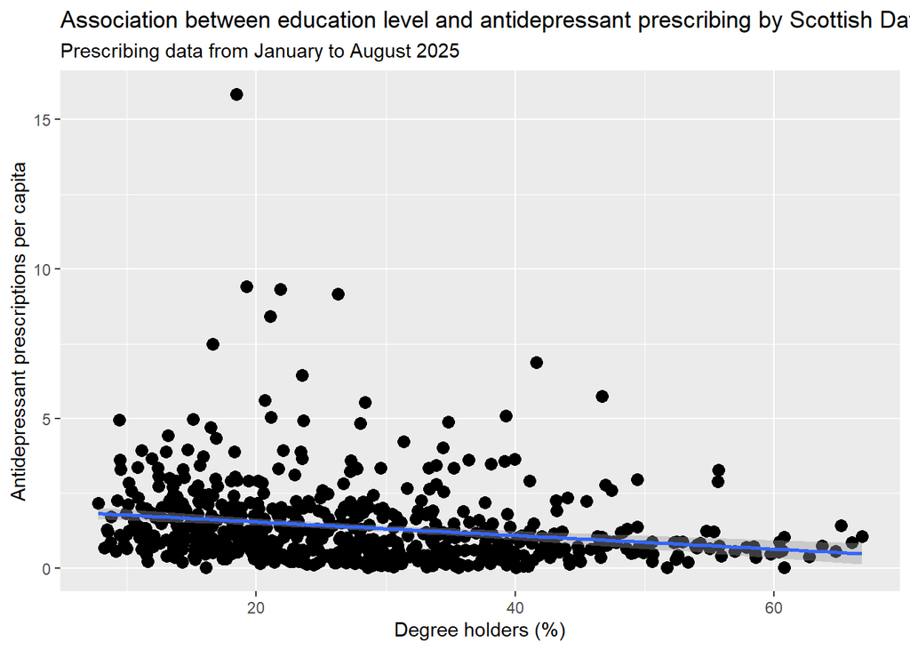

```r
antidepressants_education_dz <- antidepressants_education_dz %>%
  mutate(apc = mean_items/total, # antidepressants per capita
         degree_pct = (degree_level_qualifications_or_above_education_qualifications_not_already_mentioned_including_foreign_qualifications/total)*100) # degree holder percentage for each data zone

ggplot(antidepressants_education_dz, aes(x = degree_pct, y = apc)) +
  geom_point(size = 3) +
  geom_smooth(method = "lm", se = TRUE) +
  labs(
    x = "Degree holders (%)",
    y = "Antidepressant prescriptions per capita",
    title = "Association between education level and antidepressant prescribing by Scottish Data Zone",
    subtitle = "Prescribing data from January to August 2025"
  )
```

This graph communicates a similar relationship as the data on health boards: that a higher educational attainment is negatively correlated with antidepressant prescribing. Again though, the data doesn’t confidently support the suggestion, with only a weakly negative slope. Most of the data zones are distributed around 0-3 antidepressants per capita, with a select few outliers up near 10 and even one above 15. These few data zones with abnormally high prescribing rates are on the lower end in educational attainment, but this doesn’t reflect a cut and dry, certain relationship.

## Next Steps

Despite the uncertainty of the visualisations produced, there are still valid conclusions to be drawn from this exploration.

It is clear that there are localities with significantly high antidepressant prescribing rates relative to the rest of the country, and it’s unlikely to be a coincidence that these are areas with a relatively low education attainment rate. It would be valuable to further investigate just these outlying data zones, to identify disparities in other characteristics of the area like deficient/harmful infrastructure or local policy, insufficient access to support schemes, or disadvantageous environmental factors among many others. These are all factors that would impact both education attainment and antidepressant use, as the two are inextricably linked and involved in constant, lifelong interactions with personal, communal, and systemic aspects of being.

- table of contents with headings for each figure/visualisation
- explore dosages?
- could find geometric dataset for healthboards in scotland, then colour code the prescriptions to population ratio
- warning in census data read (line 100)
- chunk titles
- table of contents with navigation, headings to split the report up a bit(may need to revise flow somewhat)
- gt table somewhere maybe
- look over joins
- do i have to remove outlier in final graph?
- do i have to set a seed for linear regression?
- gen ai acknowledgement

## References

1. Bergvall, S., Fernström, C., Ranehill, E., & Sandberg, A. (2025). The impact of PhD studies on mental health-a longitudinal population study. Journal of health economics, 104, 103070. Advance online publication. https://doi.org/10.1016/j.jhealeco.2025.103070
2. Maguire, A., Moriarty, J., O’Reilly, D. et al. (2017). Education as a predictor of antidepressant and anxiolytic medication use after bereavement: a population-based record linkage study. Qual Life Res 26, 1251–1262. https://doi.org/10.1007/s11136-016-1440-1
3. NHS Business Services Authority. Electronic Repeat Dispensing Handbook. 2020. Available at: https://www.nhsbsa.nhs.uk/sites/default/files/2020-07/Electronic%20Dispensing%20Handbook_Digital_WEB_S-1589995676.pdf [Accessed 21 Nov 2025].
4. Hertfordshire & West Essex Integrated Care Board. (n.d.) Prescription duration guidance. Available at: https://www.hweclinicalguidance.nhs.uk/prescribing-guidance/prescription-duration-guidance-hwe-icb/ [Accessed 21 Nov 2025].